# Identifying `rtrees` Training Data

Katherine Goode

September 25, 2020

This journal contains work to identify the data used to train `rtrees` (contained in both `bulletr` and `bulletxtrctr`). We recently discovered some discrepancies between `rtrees` and the training data we were using (`hamby-comparisons.csv`, previously `features-hamby173and252.csv`). Unfortunately, the original work by Eric is not well documented, so it is difficult to know for sure which dataset was used to train the model. However, Eric recently pointed us to some [code](https://github.com/erichare/imaging-paper/blob/master/code/full_run.R), which he believes was used to train `rtrees`. Heike was able to rerun part of the code to extract data from the CSAFE database that was created by the first part of the code (scans to features). The new data (`CCFs_withlands`) contains the same number of rows the number of predictions associated with `rtrees`. I have gathered all of our work trying to determine that `CCFs_withlands` is the data used to train `rtrees` in this journal.

```r
library(cowplot)
library(dplyr)
library(ggplot2)
library(purrr)
library(randomForest)
library(tidyr)
```

# Raw Datasets

This section contains code for loading and performing initial comparisons of the raw datasets.

## Load Data

Load the data provided by Heike and CSAFE that we have been using and believed to be the training data for rtrees:

```r
hamby_comparisons <- read.csv("../../../data/raw/hamby-comparisons.csv")
```

Load the data extracted (on 2020-09-23) from the CSAFE database and corresponds to the [R script](https://github.com/erichare/imaging-paper/blob/master/code/full_run.R) Eric believes to be the one used to train `rtrees`.

```r
CCFs_withlands <- read.csv("../../../data/raw/CCFs_withlands.csv")
```

Obtain the features used to train `rtrees` for use throughout this journal:

```r
rtrees_features <- rownames(bulletxtrctr::rtrees$importance)
```

## Initial Comparisons

Dimensions of the raw datasets:

```r
dim(hamby_comparisons)
```

```
## [1] 84666    17
```

```r
dim(CCFs_withlands)
```

```
## [1] 83028    26
```

Note that `CCFs_withlands` has the same number of rows as the number of predictions associated with `rtrees`:

```r
length(bulletxtrctr::rtrees$predicted)
```

```
## [1] 83028
```

Comparing summaries of the distributions of the features used to train `rtrees` from the two datasets. Note that I even remove the observations in `hamby_comparisons` known to have tank rash (`flag == FALSE`). The main differences are seen with the distributions of `D` (distance) and `sd_D` (standard deviation of distance).

```r
summary(hamby_comparisons %>% filter(flag == FALSE) %>% select(all_of(rtrees_features)))
```

```
##       ccf            rough_cor              D                 sd_D
##  Min.   :0.01407   Min.   :-0.86978   Min.   : 0.05055   Min.   :0.780
##  1st Qu.:0.21297   1st Qu.:-0.18430   1st Qu.: 2.02162   1st Qu.:2.347
##  Median :0.27541   Median :-0.05671   Median : 2.76574   Median :2.724
##  Mean   :0.28940   Mean   :-0.07166   Mean   : 3.29264   Mean   :2.808
##  3rd Qu.:0.34822   3rd Qu.: 0.04999   3rd Qu.: 4.07658   3rd Qu.:3.208
##  Max.   :0.98110   Max.   : 0.96355   Max.   :20.79681   Max.   :7.263
##     matches         mismatches          cms             non_cms
##  Min.   : 0.000   Min.   : 0.000   Min.   : 0.0000   Min.   : 0.000
##  1st Qu.: 1.209   1st Qu.: 8.027   1st Qu.: 0.5915   1st Qu.: 3.675
##  Median : 2.230   Median : 9.494   Median : 1.1388   Median : 4.848
##  Mean   : 2.448   Mean   : 9.756   Mean   : 1.3578   Mean   : 5.345
##  3rd Qu.: 3.282   3rd Qu.:11.228   3rd Qu.: 1.7112   3rd Qu.: 6.525
##  Max.   :18.656   Max.   :33.684   Max.   :15.2131   Max.   :33.684
##    sum_peaks
##  Min.   : 0.000
##  1st Qu.: 1.638
##  Median : 2.764
##  Mean   : 3.030
##  3rd Qu.: 4.105
##  Max.   :25.990
```

```r
summary(CCFs_withlands %>% select(all_of(rtrees_features)))
```

```
##       ccf            rough_cor              D                  sd_D
##  Min.   :-0.0127   Min.   :-0.89155   Min.   :0.0003513   Min.   :0.001250
##  1st Qu.: 0.2124   1st Qu.:-0.20245   1st Qu.:0.0022353   1st Qu.:0.003698
##  Median : 0.2750   Median :-0.06423   Median :0.0026339   Median :0.004307
##  Mean   : 0.2890   Mean   :-0.08400   Mean   :0.0027578   Mean   :0.004430
##  3rd Qu.: 0.3481   3rd Qu.: 0.04686   3rd Qu.:0.0032182   3rd Qu.:0.005088
##  Max.   : 0.9811   Max.   : 0.96355   Max.   :0.0072105   Max.   :0.011110
##     matches         mismatches          cms             non_cms
##  Min.   : 0.000   Min.   : 0.000   Min.   : 0.0000   Min.   : 0.000
##  1st Qu.: 1.182   1st Qu.: 7.170   1st Qu.: 0.5893   1st Qu.: 3.218
##  Median : 2.197   Median : 8.225   Median : 1.1348   Median : 4.192
##  Mean   : 2.403   Mean   : 8.244   Mean   : 1.3432   Mean   : 4.564
##  3rd Qu.: 3.249   3rd Qu.: 9.289   3rd Qu.: 1.7082   3rd Qu.: 5.555
##  Max.   :18.656   Max.   :14.947   Max.   :15.2131   Max.   :14.161
##    sum_peaks
##  Min.   : 0.000
##  1st Qu.: 1.566
##  Median : 2.709
##  Mean   : 2.982
##  3rd Qu.: 4.062
##  Max.   :23.775
```

Comparing visualizations of the distributions of the features used to train `rtrees` from the two datasets to again see the differences in distributions of `D` and `sd_D`:

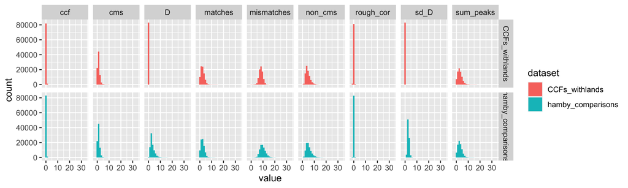

```r
bind_rows(
  hamby_comparisons %>%
    filter(flag == FALSE) %>%
    select(all_of(rtrees_features)) %>%
    pivot_longer(cols = everything()) %>%
    mutate(dataset = "hamby_comparisons"),
  CCFs_withlands %>% select(all_of(rtrees_features)) %>%
    pivot_longer(cols = everything()) %>%
    mutate(dataset = "CCFs_withlands")
) %>%
  ggplot(aes(x = value, fill = dataset)) +
  geom_histogram() +
  facet_grid(dataset ~ name)
```